# Reciept Reader

Reciept Reading OCR

**Introduction**: In this mini project I developed a script for preprocessing a reciept then running it through an Optical Character Recognition model to scan the reciept into text. With this text, I used regex to wrangle the data into a breakdown of items and their costs. The inspiration for this project was splitting a costco reciept with my roommates so the examples will follow a costco reciept through the pipeline and final output

**Imports**: I import cv2 and PIL for image processing, and pytesseract for OCR

```python
import cv2
from PIL import Image
import pytesseract
import numpy as np
import matplotlib.pyplot as plt
import math
import re

from skimage.filters import threshold_local

pytesseract.pytesseract.tesseract_cmd = r'C:\Program Files\Tesseract-OCR\tesseract.exe'
```

**Basic Functions** here I wrote a few basic functions to be called later. Kernel_getter will be used for retrieving the morphological kernel, opener is used to preform the opening operation on the image, which will break narrow isthmuses between characters, allowing for better reading, plot rgb will help use visualize our processed image)

```python
def kernel_getter(I_shape):
    return ((max(I_shape[0]//20, 1) * 4) + 1, (max(I_shape[1]//20, 1) * 4) + 1)


def opener(I):
    dimensions = kernel_getter(I.shape)
    elm = cv2.getStructuringElement(cv2.MORPH_RECT, (dimensions[0],dimensions[1]))
    out = cv2.morphologyEx(I, cv2.MORPH_OPEN, elm)
    return out

def plot_rgb(image):
    plt.figure(figsize=(16,10))
    return plt.imshow(cv2.cvtColor(image, cv2.COLOR_BGR2RGB))
```

[figure not shown]

```python
I = np.asarray(Image.open("tn1200w_15680401584732.jpeg"))
I = cv2.cvtColor(I, cv2.COLOR_BGR2GRAY)
top, bottom, left, right = 20, 20, 20, 20
border_color = [0, 0, 0]
I = cv2.copyMakeBorder(I, top, bottom, left, right, cv2.BORDER_CONSTANT, value=border_color)
plot_rgb(I)
```

1. **Image Filtering and Thresholding:**
   - Generates a kernel and performs image filtering (details not provided in the snippet).
   - Thresholds the image using Otsu's method to segment it into foreground and background.
   - Applies Gaussian blur to reduce noise in the image.

```python
ker = kernel_getter(I.shape)
blur = cv2.GaussianBlur(I, ker, 0)
th, bined = cv2.threshold(blur, 0, 255, cv2.THRESH_OTSU)
opened = opener(bined)
```

1. **Edge Detection and Contour Finding:**
   - Performs Canny edge detection to identify edges in the thresholded image.
   - Finds contours using the `cv2.findContours` function.

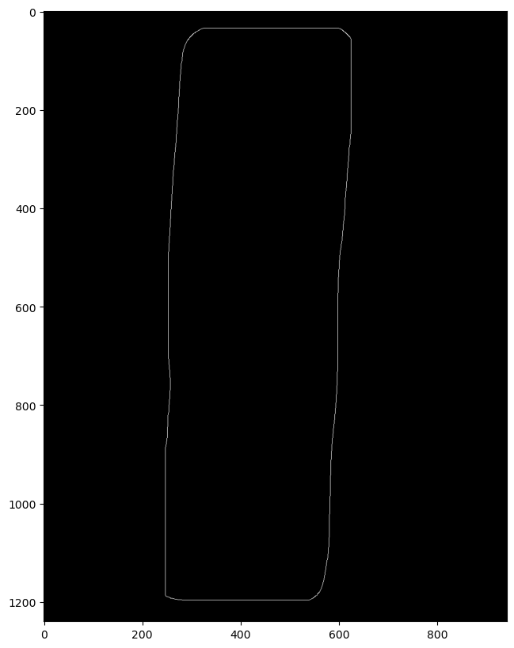

```python
edged = cv2.Canny(opened, 0, .5, apertureSize=3)
contours, hierarchy = cv2.findContours(edged, cv2.RETR_EXTERNAL, cv2.RETR_LIST)
plot_rgb(edged)
```

1. **Identifying the Receipt Area:**
   - Sorts contours based on their arc length and selects the contour with the largest arc length, assuming it represents the receipt.

```python
to_sort = np.zeros(len(contours))
for i, contour in enumerate(contours):
    to_sort[i] = cv2.arcLength(contour, False)
biggest = np.argsort(to_sort)[-1]
receipt = contours[biggest]
```

1. **Perspective Transformation:**
   - Approximates the contour of the receipt to a rectangle and transforms it into a quadrilateral with known dimensions.
   - Applies perspective transformation to warp the receipt area into a rectangular shape, facilitating OCR.

[figure not shown]

```python
epsilon = 0.1 * cv2.arcLength(receipt, True)
approx = np.array(cv2.approxPolyDP(receipt, epsilon, True))

# Get the minimum bounding rectangle
rect = cv2.minAreaRect(receipt)

# Convert the rectangle to box points
approx = cv2.boxPoints(rect)


height = np.linalg.norm(approx[0] - approx[1])
width = np.linalg.norm(approx[1] - approx[2])


dst_points = np.array([[0, height], [0, 0], [width, 0], [width, height]], dtype=np.float32)

# Compute perspective transformation matrix
M = cv2.getPerspectiveTransform(approx.astype(np.float32), dst_points)

# Warp the image
warped_image = cv2.warpPerspective(I, M, (int(width), int(height)))

# Display the warped image
plot_rgb(warped_image)
```

1. **OCR Text Extraction:**
   - Configures Tesseract OCR with custom parameters to improve accuracy.
   - Extracts text from the warped receipt image using `pytesseract.image_to_string`.
   - Uses presets to not penalize non-words/non-sentences as the receipt is not plain english

```python
custom_config = r'--oem 3 --psm 6 -c load_system_dawg=0 load_freq_dawg=0'
extracted_text = pytesseract.image_to_string(warped_image, config=custom_config)
```

**Receipt Splitting**

1. **Extracted Text Assignment:**
   - Assigns the extracted text to the variable `text`.
2. **Groceries Extraction:**
   - Uses a regular expression to find patterns matching grocery items in the text.
3. **Prices Extraction:**
   - Uses a regular expression to find patterns matching prices in the text.
4. **Price Formatting:**
   - Formats the prices by replacing spaces with dots if present.
5. **Dues Calculation:**
   - Initializes a dictionary to keep track of dues for each individual.
   - Iterates through each grocery item and asks for input about who bought the item.
   - Calculates and updates the dues for each person based on the price of the item and the number of people who bought it.

```python
text = extracted_text
groceries = re.findall(r' (.+)\d{1,2}\.\d{1,3}[^-\d]',text)
prices = re.findall(r'[^D](\d{1,3}[\. ]+\d{2})',text)
for i in range(len(prices)):
    if " " in prices[i]:
        prices[i] = prices[i].replace(" ",'.')

dues = {'a':0,'c':0,'l':0,'r':0,'v':0}
for i in range(len(groceries)):
    add_to = input("initial(s) who bought "+groceries[i])
    price = float(prices[i])
    for initial in add_to:
        dues[initial]+= price / len(add_to)
print(groceries)
```

[output not shown]